# Improving the quality of training samples

AT_ATLIBERIA

Alicia Valdés

11 marzo 2025

This scripts uses several pre-processing methods to improve the quality of training samples for machine learning classification of satellite images.

Documentation: https://e-sensing.github.io/sitsbook/improving-the-quality-of-training-samples.html

# Load libraries

```r
library(gridExtra)
```

# Load previously saved objects

These objects took a long time to generate!

```r
# List all RDS files in the folder
rds_files <- list.files(path = here("r_objects", "AT_ATLIBERIA"),
                        pattern = "\\.rds$", full.names = TRUE)

# Load all RDS files into a list
loaded_objects <- lapply(rds_files, readRDS)

# Optionally, name the list elements with the file names (without the .rds extension)
names(loaded_objects) <- basename(rds_files) %>% tools::file_path_sans_ext()

# Print the names of the loaded objects
print(names(loaded_objects))
```

```
[1] "samples_organized"
```

```r
# Assign each object to a variable in the global environment
list2env(loaded_objects, envir = .GlobalEnv)
```

```
<environment: R_GlobalEnv>
```

```r
rm(rds_files)
rm(loaded_objects)
```

# Data prep

## Implementing csv to Rstudio format

No need to run again if using saved objects!

```r
# Cargamos el csv en la ruta correspondiente.
samples <- read.csv("C:/Data/PAs/AT_ATLIBERIA_R.csv")

# Organizamos en el formato/estructura el csv para que RStudio acepte el formato.

samples_organized <- samples %>%
  pivot_wider(names_from = "band", values_from = "value") %>%  # Volver a formato ancho
  group_by(longitude, latitude, start_date, end_date, label, cube) %>%
  nest(time_series = c(Index, B02, B03, B04, B08, B09, B10))  # Anidar las bandas

samples_organized <- samples_organized %>%
  mutate(time_series = purrr::map(time_series, ~ .x %>%
                             # Convertir Index a formato Date
                             mutate(Index = as.Date(Index, format = "%Y-%m-%d"))))

# Accedemos a la primera time_series
samples_organized$time_series[[1]]

# Posiblemente en la integración de los datos puede llegar a haber en ocasiones
# errores en el formato de los campos por lo que nos aseguramos de que cada campo tenga su formato.

samples_organized <- samples_organized %>%
  mutate(
    start_date = as.Date(start_date, format = "%Y-%m-%d"),  # Convertir a formato Date
    end_date = as.Date(end_date, format = "%Y-%m-%d"),      # Convertir a formato Date
    label = as.character(label)  # Convertir a character
  )
```

## Reclassification

We cannot have label 14 = 2. Cropland together with labels 15 = 2.1. Arable land and 18 = 2.2. Permanent crops. We must reclassify 15 and 18 to 14.

```r
samples_organized <- samples_organized %>%
  mutate(label = if_else(label == "15" | label == "18", "14", label))
saveRDS(samples_organized,
        file = here("r_objects", "AT_ATLIBERIA", "samples_organized.rds"))
```

## Ungroup the samples

We need ungroup() for some algorithms to work.

```r
samples_organized_ungr <- samples_organized %>% ungroup()
```

## Transform to sits class

```r
# Se implementa como un conjunto de datos en formato 'group_dbf' y
# para aplicar los procesamientos que queremos tenemos que transformarlo a 'sits'.
class(samples_organized) <- c("sits", class(samples_organized))
class(samples_organized_ungr) <- c("sits", class(samples_organized_ungr))
```

# Obtaining samples using Rstudio (do not use)

```r
#####________________ COMANDO PARA REALIZAR LA OBTENCIÓN DE LOS SAMPLES MEDIANTE RSTUDIO ________________#####
#####________ SIMPLEMENTE AGREGADO PARA CONOCER COMO SE HA OBTENIDO EL ARCHIVO DATA (NO USADO) __________#####

# Cargamos el datacube en el formato que admite SITS.

datacube <- sits_cube(
  source = "MPC",
  collection = "SENTINEL-2-L2A",
  data_dir = "RUTA/AL/DATACUBE"
)

# Cargamos el shapefile de los puntos que solo deben contener la etiqueta 'label'.

shp_file <- "RUTA/AL/SHAPEFILE.shp"
if (file.exists(shp_file)) {
  sf_shape <- st_read(shp_file)
  print(sf_shape)
} else {
  stop("El archivo no existe en la ruta especificada.")
}
# Obtenemos el samples con el que podemos empezar a realizar los analisis.

samples <- sits_get_data(
  cube         = datacube,
  samples      = sf_shape,
  start_date = "2021-01-01",
  end_date = "2021-12-31",
  progress = TRUE
)
```

# Statistics of samples

Run on samples_organized.

```r
summary(samples_organized)
```

| label | count | prop |
| --- | --- | --- |
| 1 | 75212 | 0.0295639657 |
| 14 | 90146 | 0.0354341495 |
| 27 | 622664 | 0.2447537247 |
| 30 | 86174 | 0.0338728551 |
| 40 | 183605 | 0.0721705569 |
| 41 | 441960 | 0.1737234787 |
| 47 | 537302 | 0.2112000465 |
| 48 | 1582 | 0.0006218448 |
| 49 | 65635 | 0.0257994853 |
| 51 | 301750 | 0.1186104166 |

[output cut: 4 more lines]

# Get labels, band, head and class of the samples

```r
sits_labels(samples_organized)
```

```
 [1] "1"  "14" "27" "30" "40" "41" "47" "48" "49" "51" "52" "55" "63" "73"
```

```r
sits_bands(samples_organized)
```

```
[1] "B02" "B03" "B04" "B08" "B09" "B10"
```

```r
head(samples_organized)
```

| longitude | latitude | start_date | end_date | label | cube | time_series |
| --- | --- | --- | --- | --- | --- | --- |
| 513080.2 | 4626970 | 2021-01-01 | 2021-12-01 | 1 | SENTINEL-2-L2A |  |
| 513082.6 | 4626973 | 2021-01-01 | 2021-12-01 | 1 | SENTINEL-2-L2A |  |
| 513085.5 | 4626968 | 2021-01-01 | 2021-12-01 | 1 | SENTINEL-2-L2A |  |
| 513085.4 | 4626971 | 2021-01-01 | 2021-12-01 | 1 | SENTINEL-2-L2A |  |
| 513085.2 | 4626973 | 2021-01-01 | 2021-12-01 | 1 | SENTINEL-2-L2A |  |
| 512948.9 | 4627124 | 2021-01-01 | 2021-12-01 | 14 | SENTINEL-2-L2A |  |

```r
class(samples_organized)
```

```
[1] "sits"       "grouped_df" "tbl_df"     "tbl"        "data.frame"
```

# Self-organized map (SOM)

## Creating the SOM map

Clustering technique based on self-organizing maps (SOM). It is a dimensionality reduction technique where high-dimensional data is mapped into a two-dimensional map, keeping the topological relations between data patterns. The SOM 2D map is composed of “neurons”. Each neuron has a weight vector, with the same dimension as the training samples. At the start, neurons are assigned a small random value and then trained by competitive learning. The algorithm computes the distances of each member of the training set to all neurons and finds the neuron closest to the input, called the best matching unit.

### Grid 15 x 15

```r
samples_SOM_cluster <- sits_som_map(samples_organized_ungr,
                                    grid_xdim = 15,
                                    grid_ydim = 15,
                                    alpha = 1.0,
                                    distance = "dtw",
                                    rlen = 20)
saveRDS(samples_SOM_cluster,
        file = here("r_objects", "AT_ATLIBERIA", "samples_SOM_cluster.rds"))
```

Plots for the SOM map (different bands).

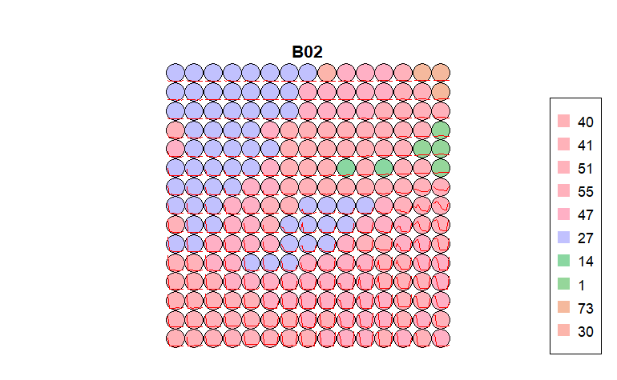

```r
plot(samples_SOM_cluster, band = "B02")
```

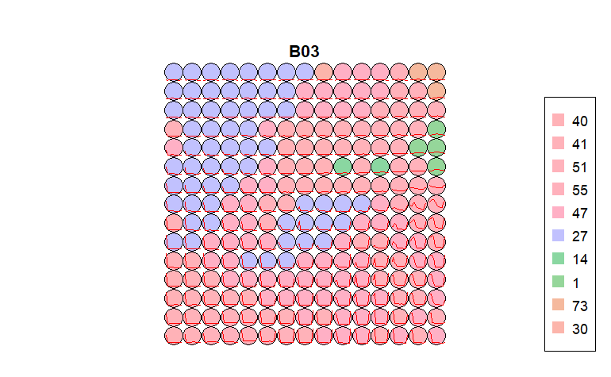

```r
plot(samples_SOM_cluster, band = "B03")
```

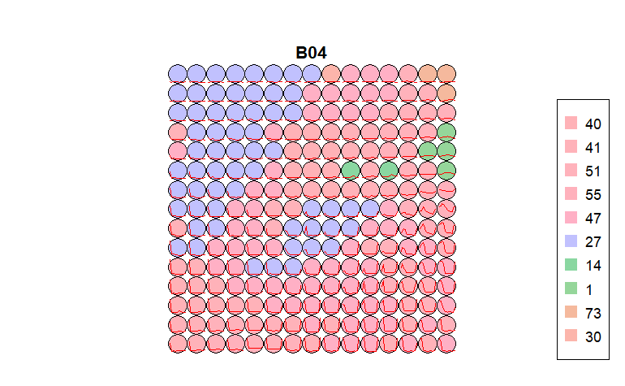

```r
plot(samples_SOM_cluster, band = "B04")
```

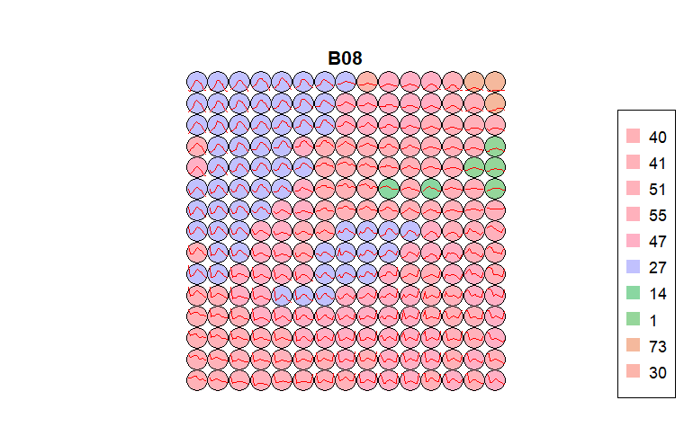

```r
plot(samples_SOM_cluster, band = "B08")
```

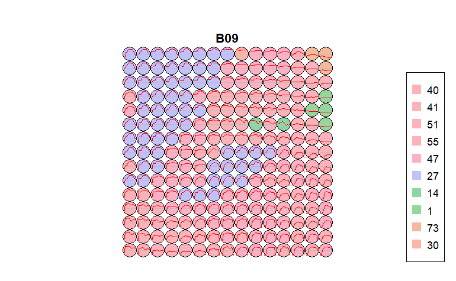

```r
plot(samples_SOM_cluster, band = "B09")
```

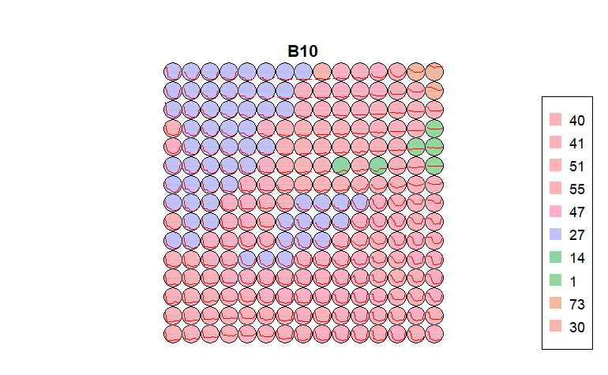

```r
plot(samples_SOM_cluster, band = "B10")
```

See what to do with warning about the colors - not sure why the labels have so similar colors in the plot. Might need to change the color palette, but not sure how.

### Grid 25 x 25

```r
samples_SOM_cluster_25 <- sits_som_map(samples_organized_ungr,
                                    grid_xdim = 25,
                                    grid_ydim = 25,
                                    alpha = 1.0,
                                    distance = "dtw",
                                    rlen = 20)
saveRDS(samples_SOM_cluster_25,
        file = here("r_objects", "AT_ATLIBERIA", "samples_SOM_cluster_25.rds"))
```

## Measuring confusion between labels using SOM

The function sits_som_evaluate_cluster() groups neurons by their majority label and produces a tibble. Neurons are grouped into clusters, and there will be as many clusters as there are labels. The results shows the percentage of samples of each label in each cluster. Ideally, all samples of each cluster would have the same label. In practice, clusters contain samples with different labels. This information helps on measuring the confusion between samples.

```r
som_eval <- sits_som_evaluate_cluster(samples_SOM_cluster)
som_eval_25 <- sits_som_evaluate_cluster(samples_SOM_cluster_25)
```

Plot confusion between clusters.

```r
som_eval
```

| id_cluster | cluster | class | mixture_percentage |
| --- | --- | --- | --- |
| 1 | 1 | 1 | 39.676356008 |
| 1 | 1 | 14 | 4.150434522 |
| 1 | 1 | 27 | 0.884027570 |
| 1 | 1 | 30 | 0.461492358 |
| 1 | 1 | 40 | 0.851063830 |
| 1 | 1 | 41 | 4.054540006 |
| 1 | 1 | 47 | 3.575067426 |
| 1 | 1 | 48 | 0.017980222 |
| 1 | 1 | 49 | 0.878034162 |
| 1 | 1 | 51 | 25.430026970 |

[output cut: 125 more lines]

```r
som_eval_25
```

| id_cluster | cluster | class | mixture_percentage |
| --- | --- | --- | --- |
| 1 | 1 | 1 | 44.081491160 |
| 1 | 1 | 14 | 5.311858350 |
| 1 | 1 | 27 | 1.511959681 |
| 1 | 1 | 30 | 0.642649529 |
| 1 | 1 | 40 | 1.223967361 |
| 1 | 1 | 41 | 4.759873070 |
| 1 | 1 | 47 | 3.797232074 |
| 1 | 1 | 48 | 0.013332978 |
| 1 | 1 | 49 | 1.597290739 |
| 1 | 1 | 51 | 18.543505507 |

[output cut: 125 more lines]

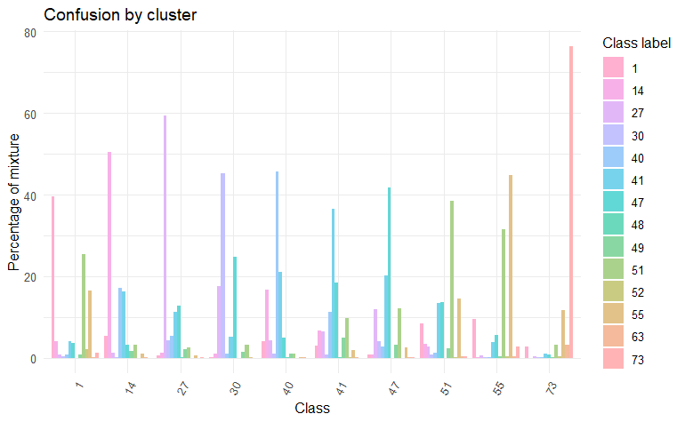

```r
plot(som_eval)
```

```
Aviso: missing colors for labels1, 14, 27, 30, 40, 41, 47, 48, 49, 51, 52, 55, 63, 73Aviso: palette for missing colors isSet3
```

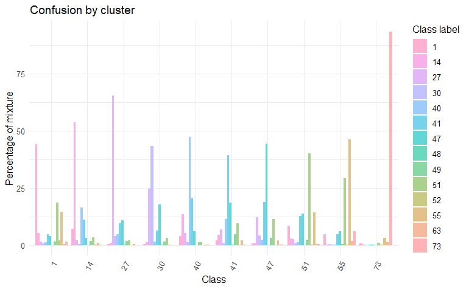

```r
plot(som_eval_25)
```

## Detecting noisy samples using SOM

This approach uses the discrete probability distribution associated with each neuron, which is included in the labeled_neurons tibble produced by sits_som_map(). This approach associates probabilities with frequency of occurrence. More homogeneous neurons (those with one label has high frequency) are assumed to be composed of good quality samples. Heterogeneous neurons (those with two or more classes with significant frequencies) are likely to contain noisy samples.

The function sits_som_clean_samples() finds out which samples are noisy, which are clean, and which need to be further examined by the user.

If the prior probability of a sample is less than prior_threshold, the sample is assumed to be noisy and tagged as “remove”.

If the prior probability is greater or equal to prior_threshold and the posterior probability calculated by Bayesian inference is greater or equal to posterior_threshold, the sample is assumed not to be noisy and thus is tagged as “clean”.

If the prior probability is greater or equal to prior_threshold and the posterior probability is less than posterior_threshold, we have a situation when the sample is part of the majority level of those assigned to its neuron, but its label is not consistent with most of its neighbors. This is an anomalous condition and is tagged as “analyze”. Users are encouraged to inspect such samples to find out whether they are in fact noisy or not.

The default value for both prior_threshold and posterior_threshold is 60%.

The sits_som_clean_samples() has an additional parameter (keep), which indicates which samples should be kept in the set based on their prior and posterior probabilities. The default for keep is c(“clean”, “analyze”).

### Grid 15 x 15

```r
thresholds <- c(0.2, 0.4, 0.6, 0.8)

results <- expand_grid(prior = thresholds, posterior = thresholds) %>%
  mutate(result = map2(prior, posterior, ~ sits_som_clean_samples(
    som_map = samples_SOM_cluster,
    prior_threshold = .x,
    posterior_threshold = .y,
    keep = c("clean", "analyze")
  ))) %>%
  mutate(result_name = paste0("samples_SOM_",
                              gsub("\\.", "", as.character(prior)),
                              "_", gsub("\\.", "", as.character(posterior))))

# Extracting results into individual variables
list2env(setNames(results$result, results$result_name), .GlobalEnv)
```

```
<environment: R_GlobalEnv>
```

```r
rm(results)
```

```r
summary(samples_SOM_02_02)
```

| label | count | prop |
| --- | --- | --- |
| 1 | 23271 | 0.01420086 |
| 14 | 34147 | 0.02083781 |
| 27 | 524618 | 0.32014201 |
| 30 | 28437 | 0.01735335 |
| 40 | 96845 | 0.05909853 |
| 41 | 261815 | 0.15976955 |
| 47 | 406568 | 0.24810338 |
| 51 | 192509 | 0.11747637 |
| 55 | 49154 | 0.02999566 |
| 73 | 21340 | 0.01302249 |

```r
summary(samples_SOM_02_04)
```

| label | count | prop |
| --- | --- | --- |
| 1 | 23271 | 0.01420086 |
| 14 | 34147 | 0.02083781 |
| 27 | 524618 | 0.32014201 |
| 30 | 28437 | 0.01735335 |
| 40 | 96845 | 0.05909853 |
| 41 | 261815 | 0.15976955 |
| 47 | 406568 | 0.24810338 |
| 51 | 192509 | 0.11747637 |
| 55 | 49154 | 0.02999566 |
| 73 | 21340 | 0.01302249 |

```r
summary(samples_SOM_02_06)
```

| label | count | prop |
| --- | --- | --- |
| 1 | 23271 | 0.01420086 |
| 14 | 34147 | 0.02083781 |
| 27 | 524618 | 0.32014201 |
| 30 | 28437 | 0.01735335 |
| 40 | 96845 | 0.05909853 |
| 41 | 261815 | 0.15976955 |
| 47 | 406568 | 0.24810338 |
| 51 | 192509 | 0.11747637 |
| 55 | 49154 | 0.02999566 |
| 73 | 21340 | 0.01302249 |

```r
summary(samples_SOM_02_08)
```

| label | count | prop |
| --- | --- | --- |
| 1 | 23271 | 0.01420086 |
| 14 | 34147 | 0.02083781 |
| 27 | 524618 | 0.32014201 |
| 30 | 28437 | 0.01735335 |
| 40 | 96845 | 0.05909853 |
| 41 | 261815 | 0.15976955 |
| 47 | 406568 | 0.24810338 |
| 51 | 192509 | 0.11747637 |
| 55 | 49154 | 0.02999566 |
| 73 | 21340 | 0.01302249 |

```r
summary(samples_SOM_04_02)
```

| label | count | prop |
| --- | --- | --- |
| 1 | 7177 | 0.008406403 |
| 14 | 8785 | 0.010289849 |
| 27 | 455882 | 0.533973487 |
| 30 | 12881 | 0.015087484 |
| 40 | 59505 | 0.069698063 |
| 41 | 34378 | 0.040266868 |
| 47 | 184841 | 0.216503817 |
| 51 | 58266 | 0.068246825 |
| 55 | 10699 | 0.012531713 |
| 73 | 21340 | 0.024995491 |

```r
summary(samples_SOM_04_04)
```

| label | count | prop |
| --- | --- | --- |
| 1 | 7177 | 0.008406403 |
| 14 | 8785 | 0.010289849 |
| 27 | 455882 | 0.533973487 |
| 30 | 12881 | 0.015087484 |
| 40 | 59505 | 0.069698063 |
| 41 | 34378 | 0.040266868 |
| 47 | 184841 | 0.216503817 |
| 51 | 58266 | 0.068246825 |
| 55 | 10699 | 0.012531713 |
| 73 | 21340 | 0.024995491 |

```r
summary(samples_SOM_04_06)
```

| label | count | prop |
| --- | --- | --- |
| 1 | 7177 | 0.008406403 |
| 14 | 8785 | 0.010289849 |
| 27 | 455882 | 0.533973487 |
| 30 | 12881 | 0.015087484 |
| 40 | 59505 | 0.069698063 |
| 41 | 34378 | 0.040266868 |
| 47 | 184841 | 0.216503817 |
| 51 | 58266 | 0.068246825 |
| 55 | 10699 | 0.012531713 |
| 73 | 21340 | 0.024995491 |

```r
summary(samples_SOM_04_08)
```

| label | count | prop |
| --- | --- | --- |
| 1 | 7177 | 0.008406403 |
| 14 | 8785 | 0.010289849 |
| 27 | 455882 | 0.533973487 |
| 30 | 12881 | 0.015087484 |
| 40 | 59505 | 0.069698063 |
| 41 | 34378 | 0.040266868 |
| 47 | 184841 | 0.216503817 |
| 51 | 58266 | 0.068246825 |
| 55 | 10699 | 0.012531713 |
| 73 | 21340 | 0.024995491 |

```r
summary(samples_SOM_06_02)
```

| label | count | prop |
| --- | --- | --- |
| 14 | 8785 | 0.02287975 |
| 27 | 326396 | 0.85006928 |
| 41 | 10829 | 0.02820316 |
| 47 | 22110 | 0.05758352 |
| 73 | 15844 | 0.04126429 |

```r
summary(samples_SOM_06_04)
```

| label | count | prop |
| --- | --- | --- |
| 14 | 8785 | 0.02287975 |
| 27 | 326396 | 0.85006928 |
| 41 | 10829 | 0.02820316 |
| 47 | 22110 | 0.05758352 |
| 73 | 15844 | 0.04126429 |

```r
summary(samples_SOM_06_06)
```

| label | count | prop |
| --- | --- | --- |
| 14 | 8785 | 0.02287975 |
| 27 | 326396 | 0.85006928 |
| 41 | 10829 | 0.02820316 |
| 47 | 22110 | 0.05758352 |
| 73 | 15844 | 0.04126429 |

```r
summary(samples_SOM_06_08)
```

| label | count | prop |
| --- | --- | --- |
| 14 | 8785 | 0.02287975 |
| 27 | 326396 | 0.85006928 |
| 41 | 10829 | 0.02820316 |
| 47 | 22110 | 0.05758352 |
| 73 | 15844 | 0.04126429 |

```r
summary(samples_SOM_08_02)
```

| label | count | prop |
| --- | --- | --- |
| 27 | 90582 | 0.8511266 |
| 73 | 15844 | 0.1488734 |

```r
summary(samples_SOM_08_04)
```

| label | count | prop |
| --- | --- | --- |
| 27 | 90582 | 0.8511266 |
| 73 | 15844 | 0.1488734 |

```r
summary(samples_SOM_08_06)
```

| label | count | prop |
| --- | --- | --- |
| 27 | 90582 | 0.8511266 |
| 73 | 15844 | 0.1488734 |

```r
summary(samples_SOM_08_08)
```

| label | count | prop |
| --- | --- | --- |
| 27 | 90582 | 0.8511266 |
| 73 | 15844 | 0.1488734 |

Further analysis includes calculating the SOM map and confusion matrix for the new set.

### Grid 25 x 25

```r
thresholds <- c(0.2, 0.4, 0.6, 0.8)

results <- expand_grid(prior = thresholds, posterior = thresholds) %>%
  mutate(result = map2(prior, posterior, ~ sits_som_clean_samples(
    som_map = samples_SOM_cluster_25,
    prior_threshold = .x,
    posterior_threshold = .y,
    keep = c("clean", "analyze")
  ))) %>%
  mutate(result_name = paste0("samples_SOM_25_",
                              gsub("\\.", "", as.character(prior)),
                              "_", gsub("\\.", "", as.character(posterior))))

# Extracting results into individual variables
list2env(setNames(results$result, results$result_name), .GlobalEnv)
```

```
<environment: R_GlobalEnv>
```

```r
rm(results)
```

```r
summary(samples_SOM_25_02_02)
```

| label | count | prop |
| --- | --- | --- |
| 1 | 25226 | 0.01480152 |
| 14 | 37799 | 0.02217880 |
| 27 | 529127 | 0.31046861 |
| 30 | 34559 | 0.02027771 |
| 40 | 106136 | 0.06227597 |
| 41 | 282709 | 0.16588129 |
| 47 | 416712 | 0.24450840 |
| 51 | 199186 | 0.11687364 |
| 55 | 51443 | 0.03018451 |
| 73 | 21388 | 0.01254954 |

```r
summary(samples_SOM_25_02_04)
```

| label | count | prop |
| --- | --- | --- |
| 1 | 25226 | 0.01480152 |
| 14 | 37799 | 0.02217880 |
| 27 | 529127 | 0.31046861 |
| 30 | 34559 | 0.02027771 |
| 40 | 106136 | 0.06227597 |
| 41 | 282709 | 0.16588129 |
| 47 | 416712 | 0.24450840 |
| 51 | 199186 | 0.11687364 |
| 55 | 51443 | 0.03018451 |
| 73 | 21388 | 0.01254954 |

```r
summary(samples_SOM_25_02_06)
```

| label | count | prop |
| --- | --- | --- |
| 1 | 25226 | 0.01480152 |
| 14 | 37799 | 0.02217880 |
| 27 | 529127 | 0.31046861 |
| 30 | 34559 | 0.02027771 |
| 40 | 106136 | 0.06227597 |
| 41 | 282709 | 0.16588129 |
| 47 | 416712 | 0.24450840 |
| 51 | 199186 | 0.11687364 |
| 55 | 51443 | 0.03018451 |
| 73 | 21388 | 0.01254954 |

```r
summary(samples_SOM_25_02_08)
```

| label | count | prop |
| --- | --- | --- |
| 1 | 25226 | 0.01480152 |
| 14 | 37799 | 0.02217880 |
| 27 | 529127 | 0.31046861 |
| 30 | 34559 | 0.02027771 |
| 40 | 106136 | 0.06227597 |
| 41 | 282709 | 0.16588129 |
| 47 | 416712 | 0.24450840 |
| 51 | 199186 | 0.11687364 |
| 55 | 51443 | 0.03018451 |
| 73 | 21388 | 0.01254954 |

```r
summary(samples_SOM_25_04_02)
```

| label | count | prop |
| --- | --- | --- |
| 1 | 13103 | 0.01347758 |
| 14 | 20415 | 0.02099861 |
| 27 | 443576 | 0.45625674 |
| 30 | 14781 | 0.01520355 |
| 40 | 58764 | 0.06044392 |
| 41 | 67938 | 0.06988018 |
| 47 | 230423 | 0.23701023 |
| 51 | 85474 | 0.08791749 |
| 55 | 18685 | 0.01921916 |
| 73 | 19048 | 0.01959254 |

```r
summary(samples_SOM_25_04_04)
```

| label | count | prop |
| --- | --- | --- |
| 1 | 13103 | 0.01347758 |
| 14 | 20415 | 0.02099861 |
| 27 | 443576 | 0.45625674 |
| 30 | 14781 | 0.01520355 |
| 40 | 58764 | 0.06044392 |
| 41 | 67938 | 0.06988018 |
| 47 | 230423 | 0.23701023 |
| 51 | 85474 | 0.08791749 |
| 55 | 18685 | 0.01921916 |
| 73 | 19048 | 0.01959254 |

```r
summary(samples_SOM_25_04_06)
```

| label | count | prop |
| --- | --- | --- |
| 1 | 13103 | 0.01347758 |
| 14 | 20415 | 0.02099861 |
| 27 | 443576 | 0.45625674 |
| 30 | 14781 | 0.01520355 |
| 40 | 58764 | 0.06044392 |
| 41 | 67938 | 0.06988018 |
| 47 | 230423 | 0.23701023 |
| 51 | 85474 | 0.08791749 |
| 55 | 18685 | 0.01921916 |
| 73 | 19048 | 0.01959254 |

```r
summary(samples_SOM_25_04_08)
```

| label | count | prop |
| --- | --- | --- |
| 1 | 13103 | 0.01347758 |
| 14 | 20415 | 0.02099861 |
| 27 | 443576 | 0.45625674 |
| 30 | 14781 | 0.01520355 |
| 40 | 58764 | 0.06044392 |
| 41 | 67938 | 0.06988018 |
| 47 | 230423 | 0.23701023 |
| 51 | 85474 | 0.08791749 |
| 55 | 18685 | 0.01921916 |
| 73 | 19048 | 0.01959254 |

```r
summary(samples_SOM_25_06_02)
```

| label | count | prop |
| --- | --- | --- |
| 1 | 2046 | 0.004189627 |
| 14 | 12568 | 0.025735693 |
| 27 | 369853 | 0.757353860 |
| 40 | 15512 | 0.031764169 |
| 41 | 11000 | 0.022524875 |
| 47 | 54809 | 0.112233259 |
| 55 | 3513 | 0.007193626 |
| 73 | 19048 | 0.039004892 |

```r
summary(samples_SOM_25_06_04)
```

| label | count | prop |
| --- | --- | --- |
| 1 | 2046 | 0.004189627 |
| 14 | 12568 | 0.025735693 |
| 27 | 369853 | 0.757353860 |
| 40 | 15512 | 0.031764169 |
| 41 | 11000 | 0.022524875 |
| 47 | 54809 | 0.112233259 |
| 55 | 3513 | 0.007193626 |
| 73 | 19048 | 0.039004892 |

```r
summary(samples_SOM_25_06_06)
```

| label | count | prop |
| --- | --- | --- |
| 1 | 2046 | 0.004189627 |
| 14 | 12568 | 0.025735693 |
| 27 | 369853 | 0.757353860 |
| 40 | 15512 | 0.031764169 |
| 41 | 11000 | 0.022524875 |
| 47 | 54809 | 0.112233259 |
| 55 | 3513 | 0.007193626 |
| 73 | 19048 | 0.039004892 |

```r
summary(samples_SOM_25_06_08)
```

| label | count | prop |
| --- | --- | --- |
| 1 | 2046 | 0.004189627 |
| 14 | 12568 | 0.025735693 |
| 27 | 369853 | 0.757353860 |
| 40 | 15512 | 0.031764169 |
| 41 | 11000 | 0.022524875 |
| 47 | 54809 | 0.112233259 |
| 55 | 3513 | 0.007193626 |
| 73 | 19048 | 0.039004892 |

```r
summary(samples_SOM_25_08_02)
```

| label | count | prop |
| --- | --- | --- |
| 14 | 12568 | 0.07319531 |
| 27 | 140988 | 0.82110597 |
| 73 | 18149 | 0.10569873 |

```r
summary(samples_SOM_25_08_04)
```

| label | count | prop |
| --- | --- | --- |
| 14 | 12568 | 0.07319531 |
| 27 | 140988 | 0.82110597 |
| 73 | 18149 | 0.10569873 |

```r
summary(samples_SOM_25_08_06)
```

| label | count | prop |
| --- | --- | --- |
| 14 | 12568 | 0.07319531 |
| 27 | 140988 | 0.82110597 |
| 73 | 18149 | 0.10569873 |

```r
summary(samples_SOM_25_08_08)
```

| label | count | prop |
| --- | --- | --- |
| 14 | 12568 | 0.07319531 |
| 27 | 140988 | 0.82110597 |
| 73 | 18149 | 0.10569873 |

### Summary

```r
samples_SOM <- bind_rows(
  summary(samples_SOM_02_02) %>%
    mutate(prior_threshold = 0.2, posterior_threshold = 0.2),
  summary(samples_SOM_04_02) %>%
    mutate(prior_threshold = 0.4, posterior_threshold = 0.2),
  summary(samples_SOM_06_02) %>%
    mutate(prior_threshold = 0.6, posterior_threshold = 0.2),
  summary(samples_SOM_08_02) %>%
    mutate(prior_threshold = 0.8, posterior_threshold = 0.2),
  summary(samples_SOM_02_04) %>%
    mutate(prior_threshold = 0.2, posterior_threshold = 0.4),
  summary(samples_SOM_04_04) %>%
    mutate(prior_threshold = 0.4, posterior_threshold = 0.4),
  summary(samples_SOM_06_04) %>%
    mutate(prior_threshold = 0.6, posterior_threshold = 0.4),
  summary(samples_SOM_08_04) %>%
    mutate(prior_threshold = 0.8, posterior_threshold = 0.4),
  summary(samples_SOM_02_06) %>%
    mutate(prior_threshold = 0.2, posterior_threshold = 0.6),
  summary(samples_SOM_04_06) %>%
    mutate(prior_threshold = 0.4, posterior_threshold = 0.6),
  summary(samples_SOM_06_06) %>%
    mutate(prior_threshold = 0.6, posterior_threshold = 0.6),
  summary(samples_SOM_08_06) %>%
    mutate(prior_threshold = 0.8, posterior_threshold = 0.6),
  summary(samples_SOM_02_08) %>%
    mutate(prior_threshold = 0.2, posterior_threshold = 0.8),
  summary(samples_SOM_04_08) %>%
    mutate(prior_threshold = 0.4, posterior_threshold = 0.8),
  summary(samples_SOM_06_08) %>%
    mutate(prior_threshold = 0.6, posterior_threshold = 0.8),
  summary(samples_SOM_08_08) %>%
    mutate(prior_threshold = 0.8, posterior_threshold = 0.8)
  )
samples_SOM %>% group_by(prior_threshold, posterior_threshold) %>%
  summarise(n_labels = n())
```

```r
samples_SOM_25 <- bind_rows(
  summary(samples_SOM_25_02_02) %>%
    mutate(prior_threshold = 0.2, posterior_threshold = 0.2),
  summary(samples_SOM_25_04_02) %>%
    mutate(prior_threshold = 0.4, posterior_threshold = 0.2),
  summary(samples_SOM_25_06_02) %>%
    mutate(prior_threshold = 0.6, posterior_threshold = 0.2),
  summary(samples_SOM_25_08_02) %>%
    mutate(prior_threshold = 0.8, posterior_threshold = 0.2),
  summary(samples_SOM_25_02_04) %>%
    mutate(prior_threshold = 0.2, posterior_threshold = 0.4),
  summary(samples_SOM_25_04_04) %>%
    mutate(prior_threshold = 0.4, posterior_threshold = 0.4),
  summary(samples_SOM_25_06_04) %>%
    mutate(prior_threshold = 0.6, posterior_threshold = 0.4),
  summary(samples_SOM_25_08_04) %>%
    mutate(prior_threshold = 0.8, posterior_threshold = 0.4),
  summary(samples_SOM_25_02_06) %>%
    mutate(prior_threshold = 0.2, posterior_threshold = 0.6),
  summary(samples_SOM_25_04_06) %>%
    mutate(prior_threshold = 0.4, posterior_threshold = 0.6),
  summary(samples_SOM_25_06_06) %>%
    mutate(prior_threshold = 0.6, posterior_threshold = 0.6),
  summary(samples_SOM_25_08_06) %>%
    mutate(prior_threshold = 0.8, posterior_threshold = 0.6),
  summary(samples_SOM_25_02_08) %>%
    mutate(prior_threshold = 0.2, posterior_threshold = 0.8),
  summary(samples_SOM_25_04_08) %>%
    mutate(prior_threshold = 0.4, posterior_threshold = 0.8),
  summary(samples_SOM_25_06_08) %>%
    mutate(prior_threshold = 0.6, posterior_threshold = 0.8),
  summary(samples_SOM_25_08_08) %>%
    mutate(prior_threshold = 0.8, posterior_threshold = 0.8)
  )

samples_SOM_25 %>% group_by(prior_threshold, posterior_threshold) %>%
  summarise(n_labels = n())
```

| prior_threshold | posterior_threshold | n_labels |
| --- | --- | --- |
| 0.2 | 0.2 | 10 |
| 0.2 | 0.4 | 10 |
| 0.2 | 0.6 | 10 |
| 0.2 | 0.8 | 10 |
| 0.4 | 0.2 | 10 |
| 0.4 | 0.4 | 10 |
| 0.4 | 0.6 | 10 |
| 0.4 | 0.8 | 10 |
| 0.6 | 0.2 | 8 |
| 0.6 | 0.4 | 8 |

[output cut: 6 more lines]

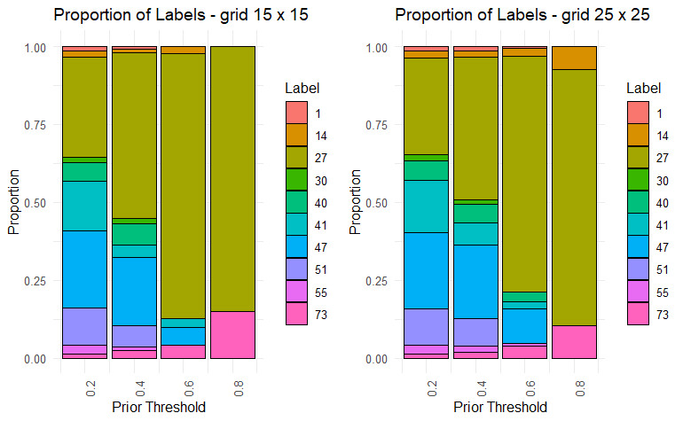

```r
grid.arrange(
  ggplot(samples_SOM %>%
           group_by(label, prior_threshold) %>%
           summarise(mean_prop = mean(prop)),
         aes(x = prior_threshold, y = mean_prop, fill = label)) +
    geom_bar(stat = "identity", color = "black", size = 0.1) +
    labs(title = "Proportion of Labels - grid 15 x 15",
         x = "Prior Threshold", y = "Proportion", fill = "Label") +
    theme_minimal() +
  theme(axis.text.x = element_text(angle = 90, hjust = 1)) +
    scale_x_continuous(breaks = c(0.2, 0.4, 0.6, 0.8)),
  ggplot(samples_SOM_25 %>%
           group_by(label, prior_threshold) %>%
           summarise(mean_prop = mean(prop)),
         aes(x = prior_threshold, y = mean_prop, fill = label)) +
    geom_bar(stat = "identity", color = "black", size = 0.1) +
    labs(title = "Proportion of Labels - grid 25 x 25",
         x = "Prior Threshold", y = "Proportion", fill = "Label") +
    theme_minimal() +
    theme(axis.text.x = element_text(angle = 90, hjust = 1)) +
    scale_x_continuous(breaks = c(0.2, 0.4, 0.6, 0.8)),
  ncol = 2)
```

## Create the new SOM maps

So far, do this only for samples_SOM_25_02_02.

Evaluate the mixture in the SOM clusters of new samples.

```r
samples_SOM_25_02_02_new_cluster <- sits_som_map(samples_SOM_25_02_02,
                                              grid_xdim = 25,
                                              grid_ydim = 25,
                                              alpha = 1.0,
                                              rlen = 20,
                                              distance = "dtw")
saveRDS(samples_SOM_25_02_02_new_cluster,
        file = here("r_objects", "AT_ATLIBERIA", "samples_SOM_25_02_02_new_cluster.rds"))
```

## Measuring confusion between labels using the new SOM map

# Reduce sample imbalance (RSI)

Sample imbalance is an undesirable property of a training set since machine learning algorithms tend to be more accurate for classes with many samples. The instances belonging to the minority group are misclassified more often than those belonging to the majority group. Thus, reducing sample imbalance can positively affect classification accuracy. The function sits_reduce_imbalance() deals with training set imbalance; it increases the number of samples of least frequent labels, and reduces the number of samples of most frequent labels.

```r
summary(samples_organized_ungr)
```

## TBD: n_samples_under

For n_samples_under, use % of cover in CLC maps (Jose).#

```r
# Aplicamos los parámetros correctos de "máximo" y "mínimo" para reducir el samples.

samples_RSI <- sits_reduce_imbalance(
  samples = samples_organized_ungr,
  n_samples_over = 200, # Min. number of samples per class. Changed (min count was 214)
  n_samples_under = 2000, # Max. number of samples per class. Changed
  multicores = 12
)

saveRDS(samples_RSI, file = here("r_objects", "AT_ATLIBERIA", "samples_RSI.rds"))
```

Print the balanced samples.

```r
summary(samples_RSI)
```

## Creating the SOM map - GRID SIZES?

```r
som_cluster_bal <- sits_som_map(
  data = samples_RSI,
  grid_xdim = 15,
  grid_ydim = 15,
  alpha = 1.0,
  distance = "dtw",
  rlen = 20,
  mode = "pbatch" # Not sure why this one, from https://e-sensing.github.io/sitsbook/improving-the-quality-of-training-samples.html
  )

saveRDS(som_cluster_bal, file = here("r_objects", "AT_ATLIBERIA", "som_cluster_bal.rds"))
```

Plots.

```r
plot(som_cluster_bal, band = "B02")
plot(som_cluster_bal, band = "B03")
plot(som_cluster_bal, band = "B04")
plot(som_cluster_bal, band = "B08")
plot(som_cluster_bal, band = "B09")
plot(som_cluster_bal, band = "B10")
```

## Measuring confusion between labels using SOM

Produce a tibble with a summary of the mixed labels.

```r
som_eval_RSI <- sits_som_evaluate_cluster(som_cluster_bal)
```

Plot confusion between clusters.

```r
som_eval_RSI
plot(som_eval_RSI)
```

Again warning about colors and missing labels on the graph.

# Cross-validation

## Original dataset

Estimates the inherent prediction error of a model. Uses only the training samples. It is a measure of model performance on the training data, and not an estimate of overall map accuracy. Uses part of the available samples to fit the classification model and a different part to test it.

```r
# Cross-validation (uncertainties)
# Default: validation_split = 0.2 (proportion of original time series set to be used for validation)
# Default: Machine learning method (sits_rfor())
# There is also sits_kfold_validate
# https://e-sensing.github.io/sitsbook/improving-the-quality-of-training-samples.html#cross-validation-of-training-sets

cross_val <- sits_validate(samples_organized)
saveRDS(cross_val, file = here("r_objects", "AT_ATLIBERIA", "cross_val.rds"))

# Shows ca. 80% accuracy
# However, this accuracy does not guarantee a good classification result.
# It only shows if the training data is internally consistent.
# (https://e-sensing.github.io/sitsbook/improving-the-quality-of-training-samples.html)
```

A high accuracy here does not guarantee a good classification result. It only shows if the training data is internally consistent. Cross-validation measures how well the model fits the training data. Using these results to measure classification accuracy is only valid if the training data is a good sample of the entire dataset.

## SOM

So far, do this only for samples_SOM_25_02_02.

```r
cross_val_samples_SOM_25_02_02_new_cluster <- sits_validate(samples_SOM_25_02_02.)
saveRDS(cross_val_samples_SOM_25_02_02_new_cluster,
        file = here("r_objects", "AT_ATLIBERIA", "cross_val_samples_SOM_25_02_02_new_cluster.rds"))
```

```r
cross_val_samples_SOM_25_02_02_new_cluster
```

## RSI

```r
cross_val_RSI <- sits_validate(samples_RSI)
saveRDS(cross_val_RSI, file = here("r_objects", "AT_ATLIBERIA", "cross_val_RSI.rds"))
```